# 3 구글로 분석할 데이터 알아보기

```python
from IPython.display import Image
```

## 3-1 구글 데이터세트 서치

- 다양한 데이터를 확인하기 위한 검색엔진 제공

https://datasetsearch.research.google.com/

```python
Image("./이미지/구글데이터세트서치.gif", width= 700, height = 700)
```

[output not shown]

## 3-2 신용카드 사기탐지 데이터 조회

- 신용카드 사기 데이터를 조회

```python
Image("./이미지/데이터세트검색결과.gif", width= 700, height = 700)
```

[output not shown]

## 인공지능, 머신러닝, 딥러닝의 관계

- 인공지능은 머신러닝과 딥러닝 이외에도 다양한 기법을 사용
- 머신러닝 내의 하나의 분야로 딥러닝

```python
Image("./이미지/인공지능세부정리.gif", width= 700, height = 700)
```

[output not shown]

```python
Image("./이미지/머신러닝딥러닝.gif", width= 700, height = 700)
```

[output not shown]

### 머신러닝과 딥러닝이 차이

- 딥러닝은 다양한 히든 계층을 가지고 복잡한 계산을 처리

```python
Image("./이미지/머신러닝과딥러닝비교.gif", width= 700, height = 700)
```

[output not shown]

## 인공지능

- 빅데이터와 머신러닝 딥러닝 기술을 융합한 서비스가 인공지능
- 다양한 머신러닝 딥러닝 학습을 통해 모델을 만들고 이를 실시간 예측 서비스를 제공해야 인공지능

```python
Image("./이미지/인공지능기술.gif", width= 700, height = 700)
```

[output not shown]

## 데이터 읽기

- 깃허브는 하나의 파일을 100메가 이상 저장하지 못해서 두 개의 파일로 분리

```python
import pandas as pd
```

```python
df_1 = pd.read_csv('./data/creditcard_1.csv')
```

```python
df_1.head()
```

|  | Unnamed: 0 | Time | V1 | V2 | V3 | V4 | V5 | V6 | V7 | V8 | ... | V21 | V22 | V23 | V24 | V25 | V26 | V27 | V28 | Amount | Class |
| --- | --- | --- | --- | --- | --- | --- | --- | --- | --- | --- | --- | --- | --- | --- | --- | --- | --- | --- | --- | --- | --- |
| 0 | 202975 | 134587.0 | 0.377710 | 0.472399 | 1.090957 | 1.177058 | -0.146419 | -0.185764 | 0.151357 | -0.375070 | ... | 0.437360 | 1.860417 | 0.060128 | 0.153842 | -1.420735 | 0.054716 | 0.120592 | 0.070077 | 2.49 | 0 |
| 1 | 58897 | 48601.0 | -0.661688 | 0.882328 | 1.635973 | -0.150249 | -0.283823 | -0.650380 | 0.810066 | -0.062751 | ... | -0.271091 | -0.579497 | 0.051175 | 0.463951 | -0.270284 | 0.025728 | 0.213118 | -0.067964 | 35.99 | 0 |
| 2 | 261865 | 160217.0 | -0.228510 | 1.361116 | 1.701139 | 4.309578 | 0.375999 | 1.577252 | -0.036991 | 0.221504 | ... | 0.347634 | 1.113112 | -0.170703 | 0.454213 | -0.692020 | 0.445925 | -0.004084 | 0.215906 | 18.87 | 0 |
| 3 | 122644 | 76639.0 | -0.360865 | 0.771529 | -0.037214 | -1.210451 | 2.447703 | 3.372180 | 0.130426 | 0.935788 | ... | -0.280373 | -0.903793 | -0.050936 | 0.982980 | -0.034645 | 0.086323 | 0.266469 | 0.114350 | 5.38 | 0 |
| 4 | 164411 | 116700.0 | -3.255879 | -3.966196 | 0.384543 | 3.242526 | 1.001219 | -1.041728 | 0.060207 | -0.170940 | ... | 0.243805 | 1.595354 | 2.917166 | 0.027683 | -0.638693 | -0.199462 | 0.651578 | 0.170789 | 351.00 | 0 |

5 rows × 32 columns

### 의미없는 칼럼 삭제

```python
df_1 = df_1.drop('Unnamed: 0', axis=1)
```

```python
df_2 = pd.read_csv('./data/creditcard_2.csv')
```

```python
df_2.head()
```

|  | Unnamed: 0 | Time | V1 | V2 | V3 | V4 | V5 | V6 | V7 | V8 | ... | V21 | V22 | V23 | V24 | V25 | V26 | V27 | V28 | Amount | Class |
| --- | --- | --- | --- | --- | --- | --- | --- | --- | --- | --- | --- | --- | --- | --- | --- | --- | --- | --- | --- | --- | --- |
| 0 | 49089 | 43906.0 | 1.229452 | -0.235478 | -0.627166 | 0.419877 | 1.797014 | 4.069574 | -0.896223 | 1.036103 | ... | -0.170060 | -0.288750 | -0.130270 | 1.025935 | 0.847990 | -0.271476 | 0.060052 | 0.018104 | 1.99 | 0 |
| 1 | 154704 | 102638.0 | 2.016893 | -0.088751 | -2.989257 | -0.142575 | 2.675427 | 3.332289 | -0.652336 | 0.752811 | ... | -0.184153 | -0.089661 | 0.087188 | 0.570679 | 0.101899 | 0.620842 | -0.048958 | -0.042831 | 6.99 | 0 |
| 2 | 67247 | 52429.0 | 0.535093 | -1.469185 | 0.868279 | 0.385462 | -1.439135 | 0.368118 | -0.499370 | 0.303698 | ... | 0.028010 | -0.384708 | -0.128376 | 0.286638 | -0.136700 | 0.913904 | -0.083364 | 0.052485 | 306.16 | 0 |
| 3 | 251657 | 155444.0 | 2.128486 | -0.117215 | -1.513910 | 0.166456 | 0.359070 | -0.540072 | 0.116023 | -0.216140 | ... | -0.357993 | -0.905085 | 0.223474 | -1.075605 | -0.188519 | 0.267672 | -0.071733 | -0.072238 | 0.99 | 0 |
| 4 | 201903 | 134084.0 | 0.558593 | 1.587908 | -2.368767 | 5.124413 | 2.171788 | -0.500419 | 1.059829 | -0.254233 | ... | -0.035049 | 0.271455 | 0.381606 | 0.332001 | -0.334757 | 0.448890 | 0.168585 | 0.004955 | 30.27 | 0 |

5 rows × 32 columns

```python
df_2 = df_2.drop('Unnamed: 0', axis=1)
```

## 두 개의 파일을 하나로 합친다.

- 축이 방향은 수직으로 처리하므로 axis=0을 지정

```python
df = pd.concat([df_1, df_2], axis=0)
```

```python
df.shape
```

```
(284807, 31)
```

## 칼럼 정보는 의미의 문자로 배정

- 데이터 전처리한 결과를 의미의 칼럼명으로 지정

```python
df.columns
```

```
Index(['Time', 'V1', 'V2', 'V3', 'V4', 'V5', 'V6', 'V7', 'V8', 'V9', 'V10',
       'V11', 'V12', 'V13', 'V14', 'V15', 'V16', 'V17', 'V18', 'V19', 'V20',
       'V21', 'V22', 'V23', 'V24', 'V25', 'V26', 'V27', 'V28', 'Amount',
       'Class'],
      dtype='object')
```

```python
df.index
```

```
Int64Index([     0,      1,      2,      3,      4,      5,      6,      7,
                 8,      9,
            ...
            142394, 142395, 142396, 142397, 142398, 142399, 142400, 142401,
            142402, 142403],
           dtype='int64', length=284807)
```

```python
df.head()
```

|  | Time | V1 | V2 | V3 | V4 | V5 | V6 | V7 | V8 | V9 | ... | V21 | V22 | V23 | V24 | V25 | V26 | V27 | V28 | Amount | Class |
| --- | --- | --- | --- | --- | --- | --- | --- | --- | --- | --- | --- | --- | --- | --- | --- | --- | --- | --- | --- | --- | --- |
| 0 | 134587.0 | 0.377710 | 0.472399 | 1.090957 | 1.177058 | -0.146419 | -0.185764 | 0.151357 | -0.375070 | 0.391117 | ... | 0.437360 | 1.860417 | 0.060128 | 0.153842 | -1.420735 | 0.054716 | 0.120592 | 0.070077 | 2.49 | 0 |
| 1 | 48601.0 | -0.661688 | 0.882328 | 1.635973 | -0.150249 | -0.283823 | -0.650380 | 0.810066 | -0.062751 | -0.070629 | ... | -0.271091 | -0.579497 | 0.051175 | 0.463951 | -0.270284 | 0.025728 | 0.213118 | -0.067964 | 35.99 | 0 |
| 2 | 160217.0 | -0.228510 | 1.361116 | 1.701139 | 4.309578 | 0.375999 | 1.577252 | -0.036991 | 0.221504 | -1.403495 | ... | 0.347634 | 1.113112 | -0.170703 | 0.454213 | -0.692020 | 0.445925 | -0.004084 | 0.215906 | 18.87 | 0 |
| 3 | 76639.0 | -0.360865 | 0.771529 | -0.037214 | -1.210451 | 2.447703 | 3.372180 | 0.130426 | 0.935788 | -0.522780 | ... | -0.280373 | -0.903793 | -0.050936 | 0.982980 | -0.034645 | 0.086323 | 0.266469 | 0.114350 | 5.38 | 0 |
| 4 | 116700.0 | -3.255879 | -3.966196 | 0.384543 | 3.242526 | 1.001219 | -1.041728 | 0.060207 | -0.170940 | 0.154713 | ... | 0.243805 | 1.595354 | 2.917166 | 0.027683 | -0.638693 | -0.199462 | 0.651578 | 0.170789 | 351.00 | 0 |

5 rows × 31 columns

## 칼럼에 대한 정보 및 데이터 타입 확인

- 칼럼별 전체 건수와 메모리 사용량이 표시

```python
df.info()
```

```
<class 'pandas.core.frame.DataFrame'>
Int64Index: 284807 entries, 0 to 142403
Data columns (total 31 columns):
 #   Column  Non-Null Count   Dtype
---  ------  --------------   -----
 0   Time    284807 non-null  float64
 1   V1      284807 non-null  float64
 2   V2      284807 non-null  float64
 3   V3      284807 non-null  float64
 4   V4      284807 non-null  float64
 5   V5      284807 non-null  float64
 6   V6      284807 non-null  float64
 7   V7      284807 non-null  float64
 8   V8      284807 non-null  float64
 9   V9      284807 non-null  float64
```

[output cut: 23 more lines]

## 결측값 확인

```python
df.isnull().sum()
```

```
Time      0
V1        0
V2        0
V3        0
V4        0
V5        0
V6        0
V7        0
V8        0
V9        0
V10       0
V11       0
V12       0
V13       0
V14       0
V15       0
V16       0
V17       0
V18       0
V19       0
V20       0
V21       0
V22       0
V23       0
V24       0
V25       0
V26       0
V27       0
V28       0
Amount    0
Class     0
dtype: int64
```

## 사기와 정상에 대한 값 확인

```python
Fraud = df[df['Class']==1]
Valid = df[df['Class']==0]
outlier_fraction = len(Fraud)/float(len(Valid))
```

### 사기 건에 대한 비율을 확인

```python
f' {outlier_fraction * 100 :.2f} %'
```

```
' 0.17 %'
```

### 사기건이 아주 작다

```python
print("Fraud Cases : {}".format(len(Fraud)))
print("Valid Cases : {}".format(len(Valid)))
```

```
Fraud Cases : 492
Valid Cases : 284315
```

```python
import matplotlib.pyplot as plt
```

```python
import seaborn as sns
```

```python
%matplotlib inline
```

## 칼럼간의 상관관계 확인

```python
 correlation_matrix = df.corr()
```

## 상관관계를 히트맵으로 확인

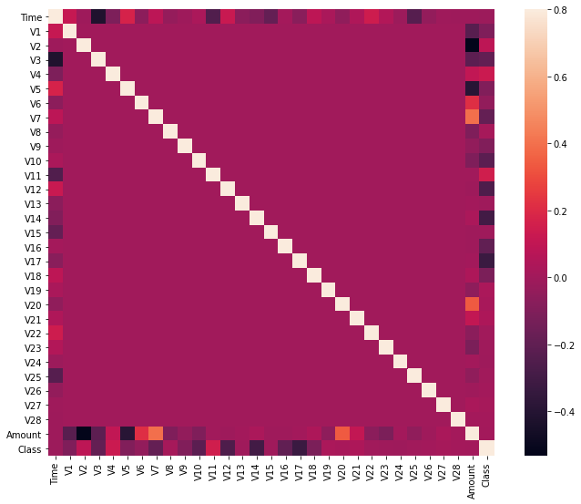

```python
fig = plt.figure(figsize=(12,9))
sns.heatmap(correlation_matrix,vmax=0.8,square = True)
plt.show()
```

## 전체 칼럼들의 분포를 확인

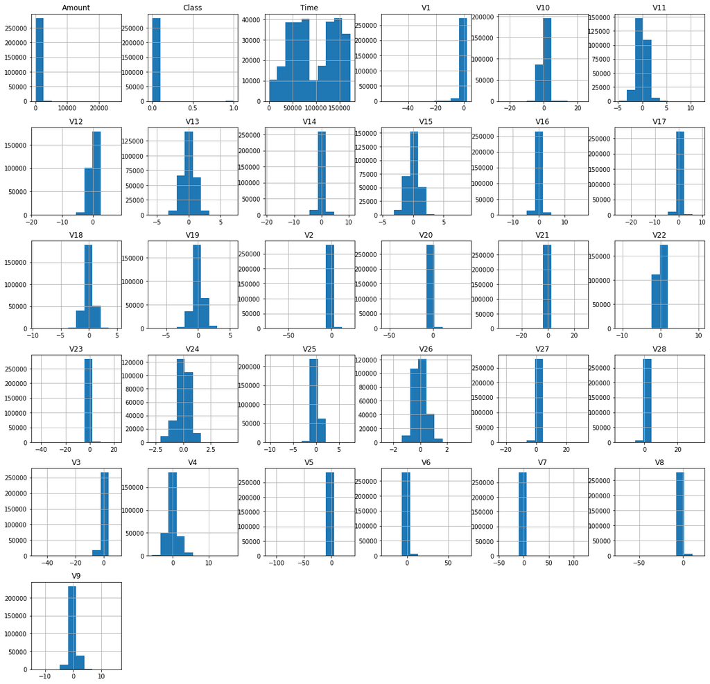

```python
df.hist(figsize=(20,20))
plt.show()
```

## 3.3 알고리즘 모듈 사용

```python
from sklearn.ensemble import IsolationForest
from sklearn.neighbors import LocalOutlierFactor
from sklearn.svm import OneClassSVM
```

### 모델에 대한 평가 함수

```python
from sklearn.metrics import classification_report, accuracy_score
```

### 데이터를 훈련과 테스트 세트로 분리

```python
from sklearn.model_selection import train_test_split
```

```python
X_train, X_test, Y_train, Y_test = train_test_split(df.drop(['Time','Class'], axis=1),
                                                    df['Class'], test_size=0.3, random_state=0)
```

```python
state= 100
```

## 임밸런스 데이터를 구분하기 위해 3개의 알고리즘을 지정

```python
classifiers = {
    "Isolation Forest":IsolationForest(n_estimators=100, max_samples=len(X_train), contamination=outlier_fraction,random_state=state, verbose=0),

    "Local Outlier Factor":LocalOutlierFactor(n_neighbors=20, algorithm='auto',  leaf_size=30, metric='minkowski',p=2, metric_params=None, contamination=outlier_fraction),

    "Support Vector Machine":OneClassSVM(kernel='rbf', degree=3, gamma=0.1,nu=0.05, max_iter=-1)

}
```

```python
Fraud_1 = Y_train[Y_train==1]
Valid_1  = Y_train[Y_train==0]
outlier_fraction = len(Fraud_1)/float(len(Valid_1))
```

```python
len(Fraud_1), len(Valid_1)
```

```
(342, 199022)
```

## 3개의 알고리즘을 학습하고 평가하기

```python
n_outliers = len(Fraud_1)
for i, (clf_name,clf) in enumerate(classifiers.items()):
    #Fit the data and tag outliers
    clf.fit(X_train)
    if clf_name == "Local Outlier Factor":
        scores_prediction = clf.negative_outlier_factor_
    elif clf_name == "Support Vector Machine":
        pass
    else:
        scores_prediction = clf.decision_function(X_train)

    if clf_name == "Local Outlier Factor":
        y_pred = clf.fit_predict(X_test)
    else :
        y_pred = clf.predict(X_test)
    #Reshape the prediction values to 0 for Valid transactions , 1 for Fraud transactions
    y_pred[y_pred == 1] = 0
    y_pred[y_pred == -1] = 1
    n_errors = (y_pred != Y_test).sum()
    # Run Classification Metrics
    print("{}: {}".format(clf_name,n_errors))
    print("Accuracy Score :")
    print(accuracy_score(Y_test,y_pred))
    print("Classification Report :")
    print(classification_report(Y_test,y_pred))
```

```
Isolation Forest: 198
Accuracy Score :
0.9976826656367402
Classification Report :
              precision    recall  f1-score   support

           0       1.00      1.00      1.00     85293
           1       0.35      0.39      0.37       150

    accuracy                           1.00     85443
   macro avg       0.68      0.69      0.68     85443
weighted avg       1.00      1.00      1.00     85443

Local Outlier Factor: 252
Accuracy Score :
0.9970506653558513
Classification Report :
              precision    recall  f1-score   support

           0       1.00      1.00      1.00     85293
           1       0.16      0.15      0.15       150

    accuracy                           1.00     85443
   macro avg       0.58      0.58      0.58     85443
weighted avg       1.00      1.00      1.00     85443

Support Vector Machine: 15605
Accuracy Score :
0.8173636225319804
Classification Report :
              precision    recall  f1-score   support

           0       1.00      0.82      0.90     85293
           1       0.01      0.83      0.02       150

    accuracy                           0.82     85443
   macro avg       0.50      0.82      0.46     85443
weighted avg       1.00      0.82      0.90     85443
```

## 3-4 부스팅 알고리즘으로 확인

```python
from xgboost import XGBClassifier
```

## 모델 생성

```python
xgb = XGBClassifier()
```

## 훈련하기

```python
xgb.fit(X_train, Y_train)
```

```
XGBClassifier(base_score=0.5, booster='gbtree', colsample_bylevel=1,
              colsample_bytree=1, gamma=0, learning_rate=0.1, max_delta_step=0,
              max_depth=3, min_child_weight=1, missing=None, n_estimators=100,
              n_jobs=1, nthread=None, objective='binary:logistic',
              random_state=0, reg_alpha=0, reg_lambda=1, scale_pos_weight=1,
              seed=None, silent=True, subsample=1)
```

## 예측하기

```python
y_pred = xgb.predict(X_test)
```

## 평가하기

```python
n_errors = (y_pred != Y_test).sum()
# Run Classification Metrics
print("{}: {}".format('xgboost',n_errors))
print("Accuracy Score :")
print(accuracy_score(Y_test,y_pred))
print("Classification Report :")
print(classification_report(Y_test,y_pred))
```

```
xgboost: 40
Accuracy Score :
0.9995318516437859
Classification Report :
              precision    recall  f1-score   support

           0       1.00      1.00      1.00     85293
           1       0.94      0.79      0.86       150

    accuracy                           1.00     85443
   macro avg       0.97      0.89      0.93     85443
weighted avg       1.00      1.00      1.00     85443
```

## 평가를 나눠서 하기

```python
from sklearn.metrics import confusion_matrix, precision_score, recall_score, f1_score
```

### 정답으로 예측한 결과가 제일 좋다

## - 사기건으로 확인 : 118 + 8 = 126 건

```python
confusion_matrix(Y_test, y_pred)
```

```
array([[85285,     8],
       [   32,   118]])
```

## 정밀도와 재현율 확인

```python
precision_score(Y_test, y_pred)
```

```
0.9365079365079365
```

```python
recall_score(Y_test, y_pred)
```

```
0.7866666666666666
```

## F1 스코어는 0.85.

```python
f1_score(Y_test, y_pred)
```

```
0.8550724637681159
```

## 3.5 텐서플로우로 확인

```python
Image("./이미지/딥러닝.gif", width= 700, height = 700)
```

[output not shown]

```python
import tensorflow as tf
```

## 딥러닝으로 처리할 때는 모든 칼럼을 정규화나 표준화 필요

```python
from sklearn.preprocessing import StandardScaler
```

```python
scaler = StandardScaler()
scaler.fit(X_train)

X_train = scaler.transform(X_train)
```

```python
X_test = scaler.transform(X_test)
```

## 하나의 히든과 출력 레이어 지정

- 과적합을 방지하기 위해 드롭아웃 레이어 추가
- 히든 레이어의 결과값 중에 30%는 출력레이어로 정보가 전달되지 않는다

```python
model = tf. keras.Sequential([
                               tf.keras.layers.Dense(32, activation='relu',input_shape=(X_train.shape[-1],)),
                               tf.keras.layers.Dropout(0.3),
                               tf.keras.layers.Dense(1, activation='sigmoid'),
                      ])
```

## 모델에 대한 손실함수, 정규화 추가

```python
model.compile(optimizer=tf.keras.optimizers.Adam(lr=1e-3), loss=tf.keras.losses.BinaryCrossentropy(), metrics=['accuracy'])
```

## 모델 훈련

```python
model.fit(X_train, Y_train, batch_size=32, epochs=20)
```

```
<tensorflow.python.keras.callbacks.History at 0x117e02910>
```

## 모델 테스트 및 평가

```python
model.evaluate(X_test, Y_test)
```

```
[0.004233833402395248, 0.9993796944618225]
```

### 테스트 결과를 반환

```python
y_pred_tf = model.predict(X_test)
```

```python
y_pred_tf.shape
```

```
(85443, 1)
```

## 분류 평가를 위한 혼동메트릭스 생성

- 사기로 예측은 105 + 8 = 113건

```python
confusion_matrix(Y_test, y_pred_tf > 0.5)
```

```
array([[85285,     8],
       [   45,   105]])
```

## F1 스코어는 0.80

```python
print(classification_report(Y_test,y_pred_tf > 0.5))
```

```
              precision    recall  f1-score   support

           0       1.00      1.00      1.00     85293
           1       0.93      0.70      0.80       150

    accuracy                           1.00     85443
   macro avg       0.96      0.85      0.90     85443
weighted avg       1.00      1.00      1.00     85443
```

```python
precision_score(Y_test, y_pred_tf > 0.5)
```

```
0.9292035398230089
```